# Immediate and Deferred Epigenomic Signatures of in-vivo Neuronal Activation in Mouse Hippocampus: A replication study

José F Carreño

2022-07-04

# Abstract

# 1. Introduction

Despite the current understanding of how neurons are able to store information for short time periods through their synapses, it is still not completely clear how they store information for longer periods [3]. However, there are evidences that changes in the nuclear elements are related to long-term information storage [1, 2, 4, 5, 6].

In this line, activity-dependent transcription promotes the refinement and plasticity of neural circuits, influencing neuronal identity, cognitive function or memory formation. Neurons use this mechanism to adapt their response to the different situations they might experience during their life [2]. The changes that occur in the nuclear elements are, among others, DNA epigenetic modifications, differences in the amount of mRNA transcripts and thereof differences in the species and amount of protein present within the cell.

This long-term information assimilation process is tightly regulated and its disruption has important consequences in the physiology of the living entity. One example is epilepsy, in which a subject undergoes recurrent unprovoked seizures, leading to disruption of brain function and deregulation of the brain activity.

The aim of this project is the replication of some of the results obtained by Fernandez-Albert, J. et al. in their work *Immediate and deferred epigenomic signatures of in vivo neuronal activation in mouse hippocampus* [1]. In the aforementioned article, the authors provide an integrated view of different elements of the neurons (chromatin changes, nuclear mRNA production, ribosomal mRNA production and Hi-C analysis) during basal state and pathological state (status epilepticus, SE). The objective of this original article was to provide insights into both the rapid changes in gene expression and the long-term changes in the nuclear elements of the neurons during processes such as epilepsy or memory formation.

# 2. Methodology and Results

## 2.1. In-vivo nuclear and ribosomal tagging

The data used during this project was obtained from the GEO repository (accesion code GSE125068) provided by the original article [1].

In order to obtain this data, the authors explored different experimental procedures on mice. First, mice were divided into Control and Treated classes, and they measured different cellular parameters on the Control mice (treated with a saline solution) and in the Treated mice after 1 hour, 6 hours and 48 hours of the injection of a Kainic Acid solution (KA). Kainic Acid is a glutamate receptor agonist that is usually used to model an epileptic seizure episode (SE).

Among the original cellular parameters measured by the authors, the ones used for this project are:

- Sequencing of nuclear RNA
- Sequencing of ribosomal RNA
- ATAC sequencing

The cells of interest were obtained after a cellular sorting procedure that relied on the fluorescent tagging of the either the nucleus or the ribosome of the forebrain principal neurons.

During the rest of this project, some of the main results obtained by the authors of the original paper will be discussed and compared to the replicated findings.

## 2.2. What are the most Differentially Expressed Genes?

The first results that will be replicated, answer to the unknown of which genes are the most differentially expressed. To address this question, it has been performed a differential expression analysis following the same procedure than in the original article. After quality control, trimming and aligning the original RNA reads, the matrix count for both the nuclear RNA (nuRNA) and the ribosomal RNA (riboRNA) have been stored in separated files.

The first step to analyze these files is to load the necessary libraries. For this project, the library used to perform the DEX analysis is `DESeq2`, widely use in scientific literature [11].

```r
suppressPackageStartupMessages({
  library(ggplot2)
  library(SummarizedExperiment)
  library(DESeq2)
})
```

Now, the files containing the SummarizedExperiment object can be read as follows:

```r
nuRNA <- readRDS("RNA/DEA_GSE125068.rds")
riboRNA <- readRDS("RNA/GSE125068_ribo.SE.rds")
```

An overview of what is inside these objects can be obtained just by using the commands:

```r
nuRNA
```

```
## class: SummarizedExperiment
## dim: 32544 8
## metadata(0):
## assays(6): counts logcpm ... norm scaledLFC
## rownames(32544): Adamts1 Arc ... Zyg11a mt-Nd6
## rowData names(1): DEA.KA
## colnames(8): GSM3562100 GSM3562101 ... GSM3562106 GSM3562107
## colData names(13): Title Tissue ... SV1 SV2
```

```r
riboRNA
```

```
## class: SummarizedExperiment
## dim: 41509 6
## metadata(0):
## assays(1): counts
## rownames(41509): 0610005C13Rik 0610006L08Rik ... Zzef1 Zzz3
## rowData names(0):
## colnames(6): SRR8441323 SRR8441324 ... SRR8441327 SRR8441328
## colData names(8): tissue source_name ... Time TimePoint
```

As it can be observed, the first SummarizedExperiment object, containing the information of the nuclear RNA sequencing has 6 different assays, where the first of them is the matrix count of the aligned RNA fragments and the second assay is the log-transform of this data. For the case of the second SummarizedExperiment object, related to the ribosomal RNA sequences, only 1 assay is present corresponding to the reads count.

For both cases the rows of each object contain the name of the genes, while the columns represent each replicate (either Control or Treated).

In the next piece of code a summary of some of the most important variables of the objects are printed.

nuRNA-seq object information:

```r
colnames(nuRNA)
```

```
## [1] "GSM3562100" "GSM3562101" "GSM3562102" "GSM3562103" "GSM3562104"
## [6] "GSM3562105" "GSM3562106" "GSM3562107"
```

```r
nuRNA$Treatment
```

```
## [1] Control     Control     Kainic Acid Kainic Acid Kainic Acid Kainic Acid
## [7] Kainic Acid Kainic Acid
## Levels: Control Kainic Acid
```

```r
head(rownames(nuRNA))
```

```
## [1] "Adamts1" "Arc"     "Arl4d"   "Arl5b"   "Btg2"    "Cenpa"
```

riboRNA-seq object information:

```r
colnames(riboRNA)
```

```
## [1] "SRR8441323" "SRR8441324" "SRR8441325" "SRR8441326" "SRR8441327"
## [6] "SRR8441328"
```

```r
riboRNA$condition
```

```
## [1] saline   saline   saline   KA 60min KA 60min KA 60min
## Levels: saline KA 60min
```

```r
head(rownames(riboRNA))
```

```
## [1] "0610005C13Rik" "0610006L08Rik" "0610009B22Rik" "0610009E02Rik"
## [5] "0610009L18Rik" "0610009O20Rik"
```

In order to work now with the DESeq2 library, it is fundamental to ensure that the objects are in the correct format.

Let’s start with the nuRNA object.

For the scope of this analysis, only the Case vs KA Treated (after 1h) data will be considered, so it is needed to discard the rest of the columns of the object. Furthermore, the variable `colData` must be added. `colData` is a data frame with a single field *Treatment* that would state if a certain replicate is a Control case or a Treated case.

```r
colData <- data.frame(nuRNA$Treatment[1:4])
rownames(colData) <- colnames(nuRNA)[1:4]
colnames(colData) <- "Treatment"
nuclear_dds<-DESeqDataSetFromMatrix(countData = assay(nuRNA)[, 1:4], design = ~ Treatment, colData = colData)
```

```
##   Note: levels of factors in the design contain characters other than
##   letters, numbers, '_' and '.'. It is recommended (but not required) to use
##   only letters, numbers, and delimiters '_' or '.', as these are safe characters
##   for column names in R. [This is a message, not a warning or an error]
```

Similarly, these steps must be replicated for the riboRNA object:

```r
colData <- data.frame("Treatment" = c("Control", "Control", "Control", "KA", "KA", "KA"))
rownames(colData) <- colnames(riboRNA)
ribo_dds<-DESeqDataSetFromMatrix(countData = round(assay(riboRNA)), design = ~ Treatment, colData = colData)
```

With the DESeq2 object the DESeq function can be now called. It will calculate the p-values of the differential expression of each gene based on the *Treatment* field. Also, a brief summary of the results obtained after the Differential Gene Expression analysis can be printed.

```r
nuclear_dds <- DESeq(nuclear_dds)
```

[output not shown]

[output not shown]

[output not shown]

```r
nuclear_res <- results(nuclear_dds)
summary(nuclear_res)
```

```
##
## out of 22219 with nonzero total read count
## adjusted p-value < 0.1
## LFC > 0 (up)       : 1232, 5.5%
## LFC < 0 (down)     : 594, 2.7%
## outliers [1]       : 0, 0%
## low counts [2]     : 7564, 34%
## (mean count < 19)
## [1] see 'cooksCutoff' argument of ?results
## [2] see 'independentFiltering' argument of ?results
```

```r
ribo_dds <- DESeq(ribo_dds)
ribo_res <- results(ribo_dds)
summary(ribo_res)
```

```
##
## out of 24248 with nonzero total read count
## adjusted p-value < 0.1
## LFC > 0 (up)       : 314, 1.3%
## LFC < 0 (down)     : 188, 0.78%
## outliers [1]       : 11, 0.045%
## low counts [2]     : 9048, 37%
## (mean count < 16)
## [1] see 'cooksCutoff' argument of ?results
## [2] see 'independentFiltering' argument of ?results
```

Finally, to compare the results obtained in this project with the original results provided in [1], two Volcano pltos are presented, one for the nuRNA-seq experiment (Control vs 1 hour KA) and one for the riboRNA-seq experiment (Control vs 1 hour KA).

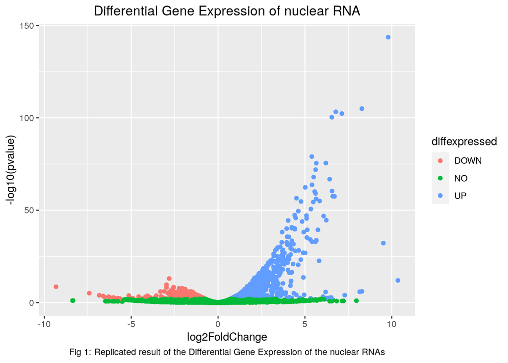

```r
p <- ggplot(data=data.frame(nuclear_res), aes(x=log2FoldChange, y=-log10(pvalue))) + geom_point()
p <- ggplot(data=data.frame(nuclear_res), aes(x=log2FoldChange, y=-log10(pvalue))) + geom_point() + theme_minimal()
p2 <- p + geom_vline(xintercept=c(-0.6, 0.6), col="red") +
    geom_hline(yintercept=-log10(0.05), col="red")


nuclear_res$diffexpressed <- "NO"
# if log2Foldchange > 0.6 and pvalue < 0.05, set as "UP"
nuclear_res$diffexpressed[nuclear_res$log2FoldChange > 0.6 & nuclear_res$pvalue < 0.01] <- "UP"
# if log2Foldchange < -0.6 and pvalue < 0.05, set as "DOWN"
nuclear_res$diffexpressed[nuclear_res$log2FoldChange < -0.6 & nuclear_res$pvalue < 0.01] <- "DOWN"

# Re-plot but this time color the points with "diffexpressed"
p <- ggplot(data=data.frame(nuclear_res), aes(x=log2FoldChange, y=-log10(pvalue), col=diffexpressed)) + geom_point() + theme_minimal()

p2 <- p + geom_vline(xintercept=c(-0.6, 0.6), col="red") +
        geom_hline(yintercept=-log10(0.05), col="red")

p3 <- p2 + scale_color_manual(values=c("blue", "black", "red"))

mycolors <- c("blue", "red", "black")
names(mycolors) <- c("DOWN", "UP", "NO")
p3 <- p2 + scale_colour_manual(values = mycolors)

nuclear_res$gene_symbol <- rownames(nuclear_res)
nuclear_res$delabel <- NA
nuclear_res$delabel[nuclear_res$diffexpressed != "NO"] <- nuclear_res$gene_symbol[nuclear_res$diffexpressed != "NO"]

ggplot(data=data.frame(nuclear_res), aes(x=log2FoldChange, y=-log10(pvalue), col=diffexpressed)) +
    geom_point() +
    theme(plot.title = element_text(hjust = 0.5), plot.caption = element_text(hjust = 0.5)) +
    labs(title = "Differential Gene Expression of nuclear RNA", caption = "Fig 1: Replicated result of the Differential Gene Expression of the nuclear RNAs")
```

For comparison purposes, the results obtained by Fernandez-Albert J. et al. is shown for the case of nuclear RNA-seq.

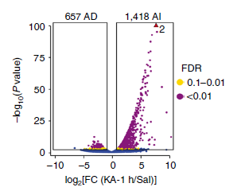

Fig 2: Original Differential Gene Expression of nuclear RNA fragments

For the case of the nuclear RNA, the number of upregulated genes found in this analysis is 1232 and the number of downregulated genes is 594. This result is in the same line than the results provided by the original paper, which reported, as shown in Fig 2, a total of 1418 upregulated genes and 657 downregulated genes.

The same comparison for the ribosomal RNA fragments can be done as:

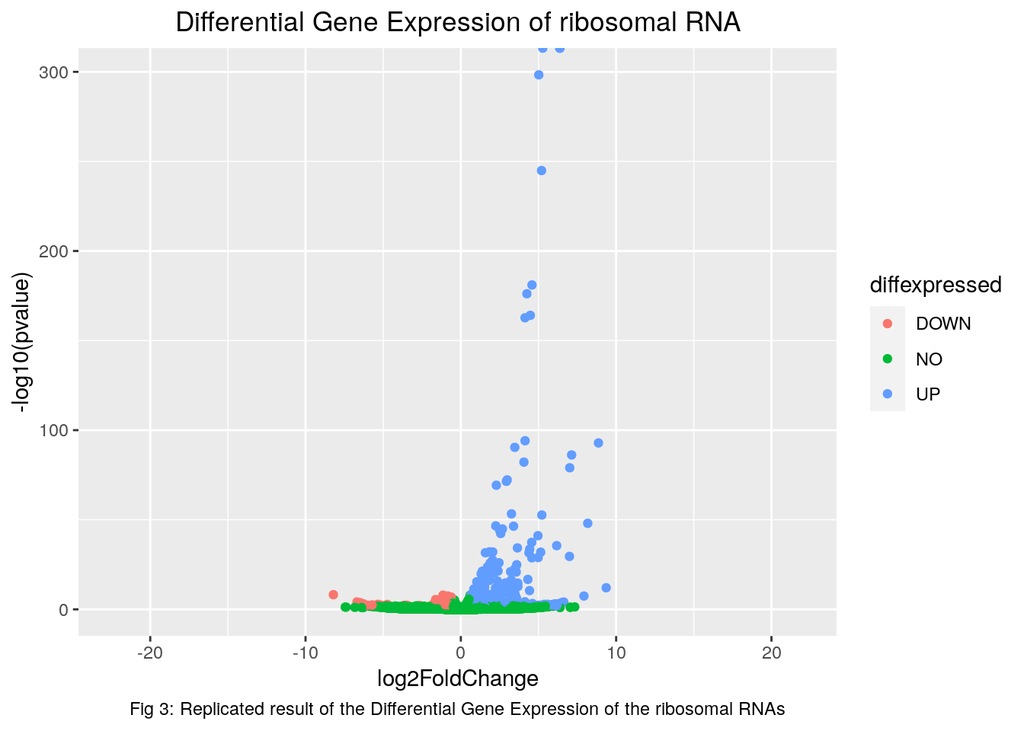

```r
p <- ggplot(data=data.frame(ribo_res), aes(x=log2FoldChange, y=-log10(pvalue))) + geom_point()
p <- ggplot(data=data.frame(ribo_res), aes(x=log2FoldChange, y=-log10(pvalue))) + geom_point() + theme_minimal()
p2 <- p + geom_vline(xintercept=c(-0.6, 0.6), col="red") +
    geom_hline(yintercept=-log10(0.05), col="red")


ribo_res$diffexpressed <- "NO"
# if log2Foldchange > 0.6 and pvalue < 0.05, set as "UP"
ribo_res$diffexpressed[ribo_res$log2FoldChange > 0.6 & ribo_res$pvalue < 0.01] <- "UP"
# if log2Foldchange < -0.6 and pvalue < 0.05, set as "DOWN"
ribo_res$diffexpressed[ribo_res$log2FoldChange < -0.6 & ribo_res$pvalue < 0.01] <- "DOWN"

# Re-plot but this time color the points with "diffexpressed"
p <- ggplot(data=data.frame(ribo_res), aes(x=log2FoldChange, y=-log10(pvalue), col=diffexpressed)) + geom_point() + theme_minimal()

p2 <- p + geom_vline(xintercept=c(-0.6, 0.6), col="red") +
        geom_hline(yintercept=-log10(0.05), col="red")



p3 <- p2 + scale_color_manual(values=c("blue", "black", "red"))

mycolors <- c("blue", "red", "black")
names(mycolors) <- c("DOWN", "UP", "NO")
p3 <- p2 + scale_colour_manual(values = mycolors)


ribo_res$gene_symbol <- rownames(ribo_res)
ribo_res$delabel <- NA
ribo_res$delabel[ribo_res$diffexpressed != "NO"] <- ribo_res$gene_symbol[ribo_res$diffexpressed != "NO"]

ggplot(data=data.frame(ribo_res), aes(x=log2FoldChange, y=-log10(pvalue), col=diffexpressed)) +
    geom_point() +
        theme(plot.title = element_text(hjust = 0.5), plot.caption = element_text(hjust = 0.5)) +
    labs(title = "Differential Gene Expression of ribosomal RNA", caption = "Fig 3: Replicated result of the Differential Gene Expression of the ribosomal RNAs")
```

And Fig 4 shows the result reported in the main article.

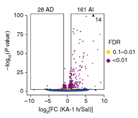

Fig 4: Original Differential Gene Expression of ribosomal RNA fragments

In both Fig 2 and Fig 4, the red triangle refers to the number of genes that are outside the range of the image axis.

Following the same analysis as for the case of the nuclear RNA sequences, the number of upregulated genes found in the replication study of the ribosomal RNA sequences is 314 while the number of downregulated genes is 188. This time, the numbers differ more from the original study, which reported 161 upregulated RNA fragments and 28 downregulated RNA fragments.

## 2.3. What is the function of the most Differentially Expressed Genes?

Once the most significant upregulated/downregulated genes are identified, it is intersting to analyse the role that each of these genes plays inside the cell. To address this question, it has been performed an enrichment analysis using the `gprofiler2` library [7] and `PANTHER` database together with `rbioapi`, which allows an easy communication method between R and `PANTHER.db` [9, 10].

```r
library(patchwork)
library(PANTHER.db)
library(rbioapi)
```

From the previous section, the names of the upregulated and the downregulated genes can be obtained for the case of the nuclear RNA sequences.

```r
up_genes_nuclear <- nuclear_res$gene_symbol[nuclear_res$diffexpressed == "UP"]
down_genes_nuclear <- nuclear_res$gene_symbol[nuclear_res$diffexpressed == "DOWN"]
```

And the same can be done for the ribosomal RNA sequences.

```r
up_genes_ribosomal <- ribo_res$gene_symbol[ribo_res$diffexpressed == "UP"]
down_genes_ribosomal <- ribo_res$gene_symbol[ribo_res$diffexpressed == "DOWN"]
```

As in the original article, the Enrichment Analysis is done with `PANTHER`. The calls to the PANTHER database can be done through the `rbioapi` package.

This library allows to perform an enrichment analysis through the command `rba_panther_enrich()`, which would take as inputs the gene names, a code for a reference genome and the type of analysis that will be performed. The following chunk of code provide information about the different analysis that are available in the `rbioapi` package.

```r
rbioapi::rba_panther_info(what = "datasets")
```

```
## Retrieving available annotation datasets.
```

[output not shown]

[output cut: 25 more lines]

In this case, only part of the results will be replicated, as only the upregulated genes identified will be studied. The enrichment analysis on the mentioned genes will account for a Molecular Function analysis, a Biological Process analysis and a Cellular Component analysis.

```r
rba_options(
  retry_max = 2,
  retry_wait = 10,
  progress = TRUE,
  timeout = 3600,
)

PANTHER_up_nuclear_MF <- rba_panther_enrich(
  up_genes_nuclear,
  10090,
  "ANNOT_TYPE_ID_PANTHER_GO_SLIM_MF",
  cutoff = 0.05)
```

```
## Performing over-representation enrichment analysis of 1195 input genes of organism 10090 against ANNOT_TYPE_ID_PANTHER_GO_SLIM_MF datasets.
```

[output not shown]

```r
PANTHER_up_nuclear_BP <- rba_panther_enrich(
  up_genes_nuclear,
  10090,
  "ANNOT_TYPE_ID_PANTHER_GO_SLIM_BP",
  cutoff = 0.05)
```

```
## Performing over-representation enrichment analysis of 1195 input genes of organism 10090 against ANNOT_TYPE_ID_PANTHER_GO_SLIM_BP datasets.
```

[output not shown]

[output cut: 102 more lines]

[output not shown]

```r
PANTHER_up_nuclear_CC <- rba_panther_enrich(
  up_genes_nuclear,
  10090,
  "ANNOT_TYPE_ID_PANTHER_GO_SLIM_CC",
  cutoff = 0.05)
```

```
## Performing over-representation enrichment analysis of 1195 input genes of organism 10090 against ANNOT_TYPE_ID_PANTHER_GO_SLIM_CC datasets.
```

[output not shown]

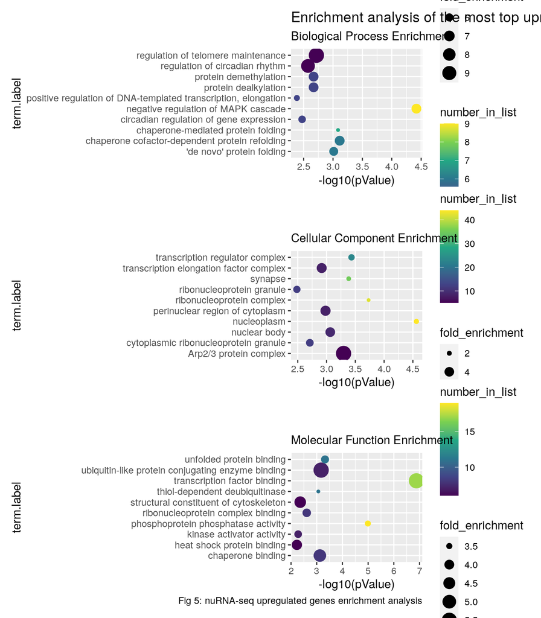

```r
# out.width= '\\textwidth', fig.height = 8, fig.align='center'}
pbp <- ggplot(head(PANTHER_up_nuclear_BP$result[order(PANTHER_up_nuclear_BP$result$fold_enrichment, decreasing = TRUE), ], 10), aes(-log10(pValue), term.label, size=fold_enrichment, color=number_in_list)) + geom_point() + scale_color_viridis_c() + labs(title = "Enrichment analysis of the most top upregulated genes in the nuRNA-seq analysis", subtitle = "Biological Process Enrichment", caption = "")

pcc <- ggplot(head(PANTHER_up_nuclear_CC$result[order(PANTHER_up_nuclear_CC$result$fold_enrichment, decreasing = TRUE), ], 10), aes(-log10(pValue), term.label, size=fold_enrichment, color=number_in_list)) + geom_point() + scale_color_viridis_c() + labs(title = "", subtitle = "Cellular Component Enrichment", caption = "")


pmf <- ggplot(head(PANTHER_up_nuclear_MF$result[order(PANTHER_up_nuclear_MF$result$fold_enrichment, decreasing = TRUE), ], 10), aes(-log10(pValue), term.label, size=fold_enrichment, color=number_in_list)) + geom_point() + scale_color_viridis_c() + labs(title = "", subtitle = "Molecular Function Enrichment", caption = "Fig 5: nuRNA-seq upregulated genes enrichment analysis")


pbp / pcc / pmf
```

Similar to what it has been done for nuclear RNA fragments, it has been done for the ribosomal RNA fragments:

```r
PANTHER_up_ribo_MF <- rba_panther_enrich(
  up_genes_ribosomal,
  10090,
  "ANNOT_TYPE_ID_PANTHER_GO_SLIM_MF",
  cutoff = 0.05)
```

```
## Performing over-representation enrichment analysis of 309 input genes of organism 10090 against ANNOT_TYPE_ID_PANTHER_GO_SLIM_MF datasets.
```

[output not shown]

```r
PANTHER_up_ribo_BP <- rba_panther_enrich(
  up_genes_ribosomal,
  10090,
  "ANNOT_TYPE_ID_PANTHER_GO_SLIM_BP",
  cutoff = 0.05)
```

```
## Performing over-representation enrichment analysis of 309 input genes of organism 10090 against ANNOT_TYPE_ID_PANTHER_GO_SLIM_BP datasets.
```

[output not shown]

[output cut: 80 more lines]

[output not shown]

```r
PANTHER_up_ribo_CC <- rba_panther_enrich(
  up_genes_ribosomal,
  10090,
  "ANNOT_TYPE_ID_PANTHER_GO_SLIM_CC",
  cutoff = 0.05)
```

```
## Performing over-representation enrichment analysis of 309 input genes of organism 10090 against ANNOT_TYPE_ID_PANTHER_GO_SLIM_CC datasets.
```

[output not shown]

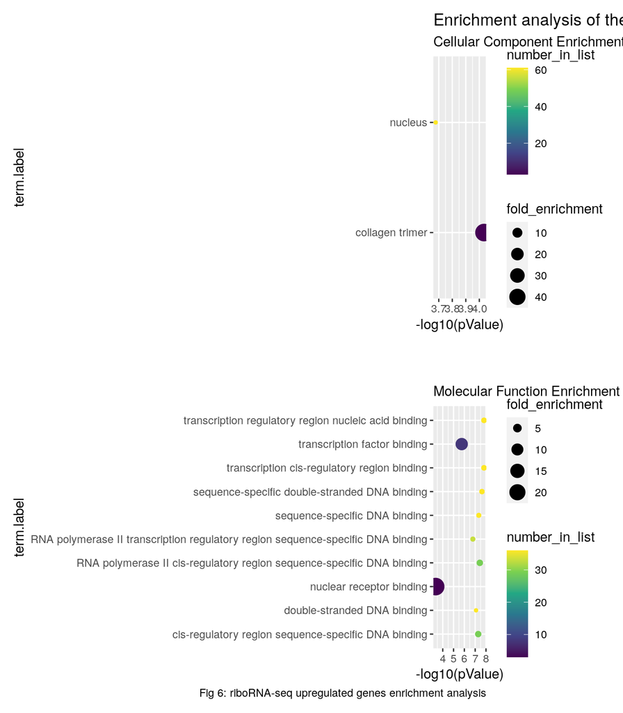

```r
#out.width= '\\textwidth', fig.height = 8, fig.align='center'}
pcc <- ggplot(head(PANTHER_up_ribo_CC$result[order(PANTHER_up_ribo_CC$result$fold_enrichment, decreasing = TRUE), ], 10), aes(-log10(pValue), term.label, size=fold_enrichment, color=number_in_list)) + geom_point() + scale_color_viridis_c() + labs(title = "Enrichment analysis of the most top upregulated genes in the riboRNA-seq analysis", subtitle = "Cellular Component Enrichment", caption = "")

pmf <- ggplot(head(PANTHER_up_ribo_MF$result[order(PANTHER_up_ribo_MF$result$fold_enrichment, decreasing = TRUE), ], 10), aes(-log10(pValue), term.label, size=fold_enrichment, color=number_in_list)) + geom_point() + scale_color_viridis_c() + labs(title = "", subtitle = "Molecular Function Enrichment", caption = "Fig 6: riboRNA-seq upregulated genes enrichment analysis")

pcc / pmf
```

For reference, the results original study are shown.

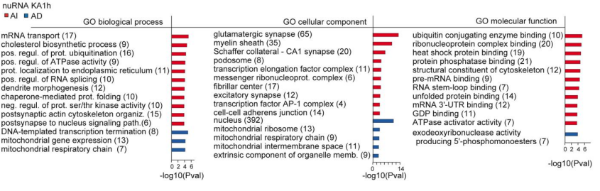

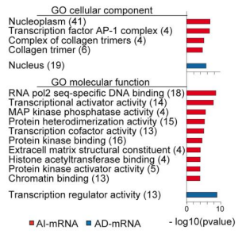

## 2.4. ATAC-seq Data Acquisition & Processing

Once the transcriptome has been analyzed, ATAC-seq data is going to be processed. The main objective of this section is to obtain and process the ATAC-seq data that will be furhter used to study the changes occurring in the DNA accessibility under the SE condition.

To do so, the first thing we need to do is to load the libraries we will be using in this section.

```r
suppressPackageStartupMessages({
  library(AnnotationHub)
  library(Rsubread)
  library(rtracklayer)
  library(Biostrings)
  library(Rfastp)
  library(epiwraps)
  library(ensembldb)
})
```

### a. Download data and fastq extraction

The ATAC data can be obtained from the GEO database with the accession code GSE125068. This data must be downloaded using the `sratoolkit`, which can be obtained through the following link:

```bash
wget http://ftp-trace.ncbi.nlm.nih.gov/sra/sdk/current/sratoolkit.current-ubuntu64.tar.gz
tar xzvf sratoolkit.current-ubuntu64.tar.gz
```

Once `sratoolkit` is available, we proceed to download the ATAC data. In summary, the relation between the replicates and the accession codes are: - SRR8441346 –> Saline condition. Replicate 1 - SRR8441347 & SRR8441348 –> Saline condition. Replicate 2 - SRR8441349 –> KA condition (1h). Replicate 1 - SRR8441350 & SRR8441351 –> KA condition (1h). Replicate 2 - SRR8441352 –> KA condition (6h). Replicate 1 - SRR8441353 –> KA condition (6h). Replicate 2 - SRR8441354 –> KA condition (48h). Replicate 1 - SRR8441355 –> KA condition (48h). Replicate 2

The `.sra` files are compressed folders that contain the information of the reads for each experiment. These files can be obtained through the `prefetch` command.

```bash
for i in SRR8441346 SRR8441347 SRR8441348 SRR8441349 SRR8441350 SRR8441351 SRR8441352 SRR8441353 SRR8441354 SRR8441355
do
   prefetch $i
done
```

However, not every `.sra` file might be available at the time of the request. To solve this problem with the accessibility of the data, the files can be directly retrieved using the following links:

```r
options(timeout=1000)
download.file('https://sra-pub-run-odp.s3.amazonaws.com/sra/SRR8441350/SRR8441350', "data/sra/SRR8441350.sra")
download.file('https://sra-pub-run-odp.s3.amazonaws.com/sra/SRR8441352/SRR8441352', "data/sra/SRR8441352.sra")
```

As shown, for the case of this project both the file `SRR8441350.sra` and the file `SRR8441352.sra` were not available at the time of the request.

Once the compressed file is available, it can be decompressed using the `fasterq-dump` command:

```bash
mkdir -p raw

for current in SRR8441346 SRR8441347 SRR8441348 SRR8441349 SRR8441350 SRR8441351 SRR8441352 SRR8441353 SRR8441354 SRR8441355
do
fasterq-dump $current --split-files --outdir raw
done
```

Notice that there are some replicates which information have been splitted into two different files. With this chunk of code, the reads of the same replicate can concatenated to analyze them at once.

```bash
cd raw

cat SRR84SRR8441347_1.fastq SRR84SRR8441348_1.fastq > SRR84SRR8441347_8_1.fastq
cat SRR84SRR8441347_2.fastq SRR84SRR8441348_2.fastq > SRR84SRR8441347_8_2.fastq

cat SRR84SRR8441350_1.fastq SRR84SRR8441351_1.fastq > SRR84SRR8441350_1_1.fastq
cat SRR84SRR8441350_2.fastq SRR84SRR8441351_2.fastq > SRR84SRR8441350_2_2.fastq

rm SRR84SRR8441347_1.fastq
rm SRR84SRR8441348_1.fastq
rm SRR84SRR8441347_2.fastq
rm SRR84SRR8441348_2.fastq

rm SRR84SRR8441350_1.fastq
rm SRR84SRR8441350_1.fastq
rm SRR84SRR8441351_2.fastq
rm SRR84SRR8441351_2.fastq
```

### b. Trimming

The next step is to discard the low quality reads from the raw data, and this is done through the `trimmomatic` tool, which allow the trimming of Illumina NGS data. This step assumes that the file `TruSeqPE.fa` is available, which contains the information about the adapters of the Illumina platform.

```bash
mkdir -p trimmed
trimmomatic PE -threads 10 raw/SRR8441346_1.fastq raw/SRR8441346_2.fastq trimmed/SRR8441346_1_paired.fastq trimmed/SRR8441346_1_unpaired.fastq trimmed/SRR8441346_2_paired.fastq trimmed/SRR8441346_2_unpaired.fastq ILLUMINACLIP:TruSeqPE:2:15:4:4:true LEADING:20 TRAILING:20 SLIDINGWINDOW:4:20 MINLEN:25
```

```bash
trimmomatic PE -threads 10 raw/SRR8441347_8_1.fastq raw/SRR8441347_8_2.fastq trimmed/SRR8441347_8_1_paired.fastq trimmed/SRR8441347_8_1_unpaired.fastq trimmed/SRR8441347_8_2_paired.fastq trimmed/SRR8441347_8_2_unpaired.fastq ILLUMINACLIP:TruSeqPE.fa:2:15:4:4:true LEADING:20 TRAILING:20 SLIDINGWINDOW:4:20 MINLEN:25
```

```bash
trimmomatic PE -threads 10 raw/SRR8441349_1.fastq raw/SRR8441349_2.fastq trimmed/SRR8441349_1_paired.fastq trimmed/SRR8441349_1_unpaired.fastq trimmed/SRR8441349_2_paired.fastq trimmed/SRR8441349_2_unpaired.fastq ILLUMINACLIP:TruSeqPE.fa:2:15:4:4:true LEADING:20 TRAILING:20 SLIDINGWINDOW:4:20 MINLEN:25
```

```bash
trimmomatic PE -threads 10 raw/SRR8441350_1_1.fastq raw/SRR8441350_1_2.fastq trimmed/SRR8441350_1_1_paired.fastq trimmed/SRR8441350_1_1_unpaired.fastq trimmed/SRR8441350_1_2_paired.fastq trimmed/SRR8441350_1_2_unpaired.fastq ILLUMINACLIP:TruSeqPE.fa:2:15:4:4:true LEADING:20 TRAILING:20 SLIDINGWINDOW:4:20 MINLEN:25
```

```bash
trimmomatic PE -threads 10 raw/SRR8441352_1.fastq raw/SRR8441352_2.fastq trimmed/SRR8441352_1_paired.fastq trimmed/SRR8441352_1_unpaired.fastq trimmed/SRR8441352_2_paired.fastq trimmed/SRR8441352_2_unpaired.fastq ILLUMINACLIP:TruSeqPE.fa:2:15:4:4:true LEADING:20 TRAILING:20 SLIDINGWINDOW:4:20 MINLEN:25
```

```bash
trimmomatic PE -threads 10 raw/SRR8441353_1.fastq raw/SRR8441353_2.fastq trimmed/SRR8441353_1_paired.fastq trimmed/SRR8441353_1_unpaired.fastq trimmed/SRR8441353_2_paired.fastq trimmed/SRR8441353_2_unpaired.fastq ILLUMINACLIP:TruSeqPE.fa:2:15:4:4:true LEADING:20 TRAILING:20 SLIDINGWINDOW:4:20 MINLEN:25
```

```bash
trimmomatic PE -threads 10 raw/SRR8441354_1.fastq raw/SRR8441354_2.fastq trimmed/SRR8441354_1_paired.fastq trimmed/SRR8441354_1_unpaired.fastq trimmed/SRR8441354_2_paired.fastq trimmed/SRR8441354_2_unpaired.fastq ILLUMINACLIP:TruSeqPE.fa:2:15:4:4:true LEADING:20 TRAILING:20 SLIDINGWINDOW:4:20 MINLEN:25
```

```bash
trimmomatic PE -threads 10 raw/SRR8441355_1.fastq raw/SRR8441355_2.fastq trimmed/SRR8441355_1_paired.fastq trimmed/SRR8441355_1_unpaired.fastq trimmed/SRR8441355_2_paired.fastq trimmed/SRR8441355_2_unpaired.fastq ILLUMINACLIP:TruSeqPE.fa:2:15:4:4:true LEADING:20 TRAILING:20 SLIDINGWINDOW:4:20 MINLEN:25
```

### c. Build Index for mm10

A necessary step right before the alignment of the top-quality reads is the creation of the index of the genome to which we are interested to align. In this case, we will create the index of the Mus Musculus genome (mm10) using the `Rsubread` package.

```r
ah <- AnnotationHub()
genome <- ah[["AH49773"]]

dir.create("mm10_genome")
export(import.2bit(genome), "mm10_genome/genome.fasta.gz", compress=TRUE)

Rsubread::buildindex("mm10_genome/rsubread", reference="mm10_genome/genome.fasta.gz")
```

### d. Align each replicate to the reference genome

With this index and the trimmed raw data of the ATAC-seq, the sequences can now be aligned.

```r
dir.create("aligned")
align.stats <- Rsubread::align(index="mm10_genome/rsubread", type="dna",
                               output_file="aligned/SRR8441346.bam",
                               readfile1="trimmed/SRR8441346_1_paired.fastq",
                               readfile2="trimmed/SRR8441346_2_paired.fastq",
                               nthreads=10, sortReadsByCoordinates=TRUE)
```

```r
align.stats <- Rsubread::align(index="mm10_genome/rsubread", type="dna",
                               output_file="aligned/SRR8441347_8.bam",
                               readfile1="trimmed/SRR8441347_8_1_paired.fastq",
                               readfile2="trimmed/SRR8441347_8_2_paired.fastq",
                               nthreads=10, sortReadsByCoordinates=TRUE)
```

```r
align.stats <- Rsubread::align(index="mm10_genome/rsubread", type="dna",
                               output_file="aligned/SRR8441349.bam",
                               readfile1="trimmed/SRR8441349_1_paired.fastq",
                               readfile2="trimmed/SRR8441349_2_paired.fastq",
                               nthreads=25, sortReadsByCoordinates=TRUE)
```

```r
align.stats <- Rsubread::align(index="mm10_genome/rsubread", type="dna",
                               output_file="aligned/SRR8441350_1.bam",
                               readfile1="trimmed/SRR8441350_1_1_paired.fastq",
                               readfile2="trimmed/SRR8441350_1_2_paired.fastq",
                               nthreads=25, sortReadsByCoordinates=TRUE)
```

```r
align.stats <- Rsubread::align(index="mm10_genome/rsubread", type="dna",
                               output_file="aligned/SRR8441352.bam",
                               readfile1="trimmed/SRR8441352_1_paired.fastq",
                               readfile2="trimmed/SRR8441352_2_paired.fastq",
                               nthreads=25, sortReadsByCoordinates=TRUE)
```

```r
align.stats <- Rsubread::align(index="mm10_genome/rsubread", type="dna",
                               output_file="aligned/SRR8441353.bam",
                               readfile1="trimmed/SRR8441353_1_paired.fastq",
                               readfile2="trimmed/SRR8441353_2_paired.fastq",
                               nthreads=25, sortReadsByCoordinates=TRUE)
```

```r
align.stats <- Rsubread::align(index="mm10_genome/rsubread", type="dna",
                               output_file="aligned/SRR8441354.bam",
                               readfile1="trimmed/SRR8441354_1_paired.fastq",
                               readfile2="trimmed/SRR8441354_2_paired.fastq",
                               nthreads=25, sortReadsByCoordinates=TRUE)
```

```r
align.stats <- Rsubread::align(index="mm10_genome/rsubread", type="dna",
                               output_file="aligned/SRR8441355.bam",
                               readfile1="trimmed/SRR8441355_1_paired.fastq",
                               readfile2="trimmed/SRR8441355_2_paired.fastq",
                               nthreads=10, sortReadsByCoordinates=TRUE)
```

### e. Peak Calling

And finally, peak calling can be done on the aligned data to obtain what are the most accessed regions in the genome for each case.

```bash
mkdir -p peaks
macs2 callpeak --outdir peaks -n SRR8441346 --gsize dm -t aligned/SRR8441346.fastq.bam --nomodel --extsize 200
```

```bash
mkdir -p peaks
macs2 callpeak --outdir peaks -n SRR8441347_8 --gsize dm -t aligned/SRR8441347_8.fastq.bam --nomodel --extsize 200
```

```bash
mkdir -p peaks
macs2 callpeak --outdir peaks -n SRR8441349 --gsize dm -t aligned/SRR8441349.fastq.bam --nomodel --extsize 200
```

```bash
mkdir -p peaks
macs2 callpeak --outdir peaks -n SRR8441350_1 --gsize dm -t aligned/SRR8441350_1.fastq.bam --nomodel --extsize 200
```

```bash
mkdir -p peaks
macs2 callpeak --outdir peaks -n SRR8441352 --gsize dm -t aligned/SRR8441352.fastq.bam --nomodel --extsize 200
```

```bash
mkdir -p peaks
macs2 callpeak --outdir peaks -n SRR8441353 --gsize dm -t aligned/SRR8441353.fastq.bam --nomodel --extsize 200
```

```bash
mkdir -p peaks
macs2 callpeak --outdir peaks -n SRR8441354 --gsize dm -t aligned/SRR8441354.fastq.bam --nomodel --extsize 200
```

```bash
mkdir -p peaks
macs2 callpeak --outdir peaks -n SRR8441355 --gsize dm -t aligned/SRR8441355.fastq.bam --nomodel --extsize 200
```

### f. Data Loading

Once the peaks have been calculated for the ATAC-seq data, we proceed to load them to Rstudio. Nevertheless, before using this information, consensus peak files can be calculated, and they will contain the peaks common to both biological replicates.

```bash
bedtools intersect -a peaks/SRR8441346_peaks.narrowPeak -b peaks/SRR8441347_8_peaks.narrowPeak > peaks/control_ATAC.narrowPeak
```

```bash
bedtools intersect -a peaks/SRR8441349_peaks.narrowPeak -b peaks/SRR8441350_1_peaks.narrowPeak > peaks/KA1h_ATAC.narrowPeak
```

```bash
bedtools intersect -a peaks/SRR8441352_peaks.narrowPeak -b peaks/SRR8441353_peaks.narrowPeak > peaks/KA6h_ATAC.narrowPeak
```

```bash
bedtools intersect -a peaks/SRR8441354_peaks.narrowPeak -b peaks/SRR8441355_peaks.narrowPeak > peaks/KA48h_ATAC.narrowPeak
```

And finally, our consensus peaks for our ATAC-seq experiments can be loaded:

```r
control_ATAC <- import("peaks/control_ATAC.narrowPeak", format="NarrowPeak")
KA1h_ATAC <- import("peaks/KA1h_ATAC.narrowPeak", format="NarrowPeak")
KA6h_ATAC <- import("peaks/KA6h_ATAC.narrowPeak", format="NarrowPeak")
KA48h_ATAC <- import("peaks/KA48h_ATAC.narrowPeak", format="NarrowPeak")
```

The coverage information for each condition in the ATAC-seq experiments, can be obtained from the original paper in the following link:

```r
dir.create("coverage")
options(timeout=10000)
download.file('https://www.ncbi.nlm.nih.gov/geo/download/?acc=GSE125068&format=file&file=GSE125068%5FATACseq%2Etar%2Egz', "coverage/ATAC-data.tar.gz")
untar("coverage/ATAC-data.tar.gz", exdir = "coverage/")
```

## 2.5. DNA Accesibility Analysis

### a. Fragment Size Distribution

As a first approach to compare the results obtained from the custom processing of the ATAC-seq data and the results from the main article, the fragment size distribution of each replicate is going to be analyzed. The conditions studied are both the Saline condition and the KA-treated condition after 1 hour.

Initially, it is needed to load the library that will be used to process the `.bam` files. This library is known as `ATACseqQC` [12].

```r
library(ATACseqQC)
library(ggplot2)
```

With the aforementioned library, the fragment size distribution can be easily calculated through the `fragSizeDist()` function, which will return the plots of the distribution of each replicate.

```r
bamFiles <- dir("aligned", "*.bam$", full.names=TRUE)
bamFiles.labels <- sub(".bam", "", basename(bamFiles[1:4]))
fragList <- fragSizeDist(bamFiles[1:4], bamFiles.labels)
```

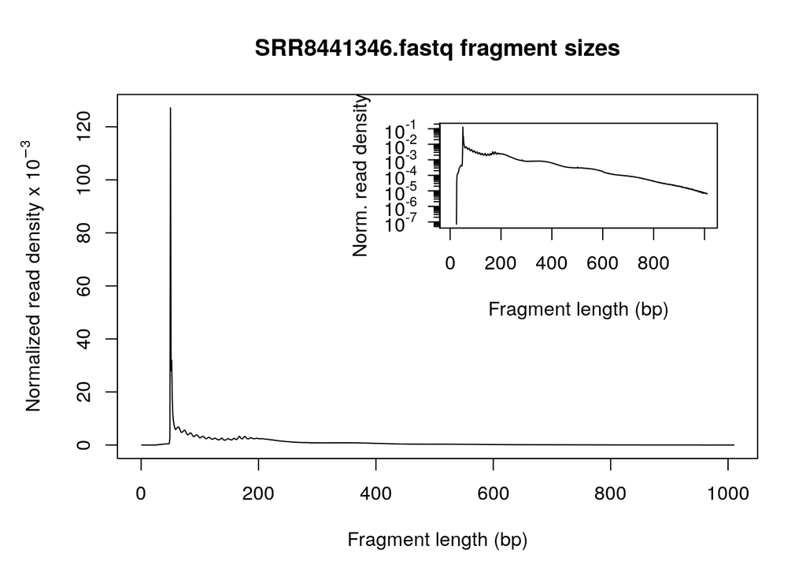

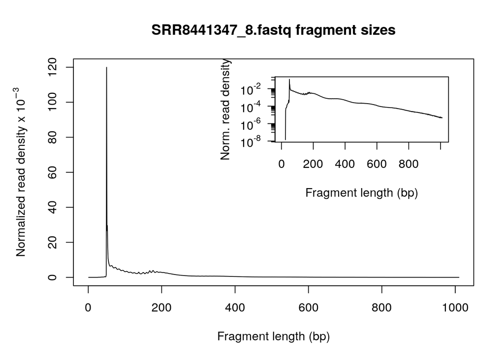

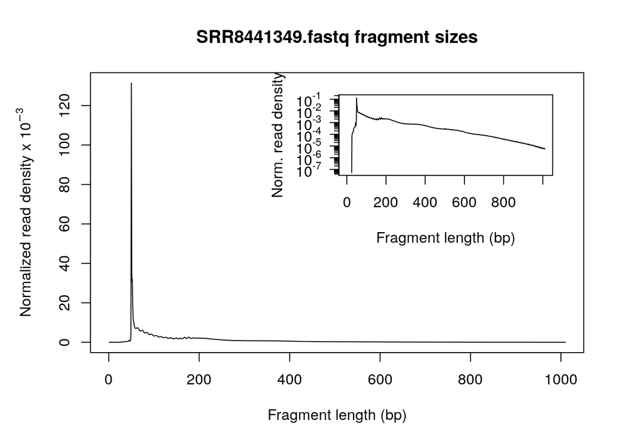

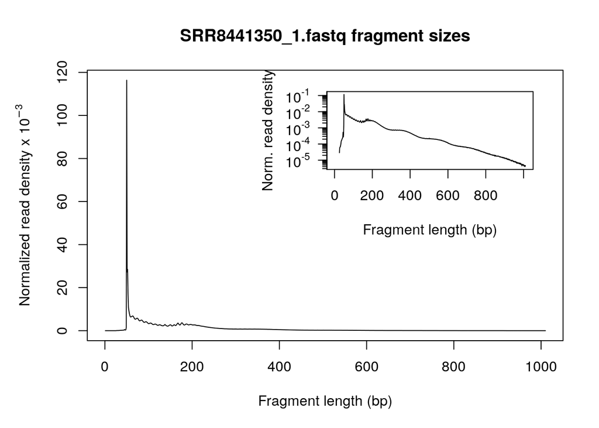

```
          Fig 8: Reads length distribution for each replicate
```

However, these plots show clear differences with respect to the results reported in the original paper.

The most noticeable difference is related to minimum fragment size. In the original paper this read length starts at 50 bp, while in the case of this replication study starts at 25 bp. Furthermore, there is a clear fragment size which is much more frequent than any other.

The strategy to evaluate what are the possible sources of error for these differences start from plotting the fragment size from position 50 as in the original paper. Furhtermore, the huge increase of counts for certain read lengths might be just outliers, so a limit can be stablished to clean this data.

After the aforementioned changes, the results are as shown:

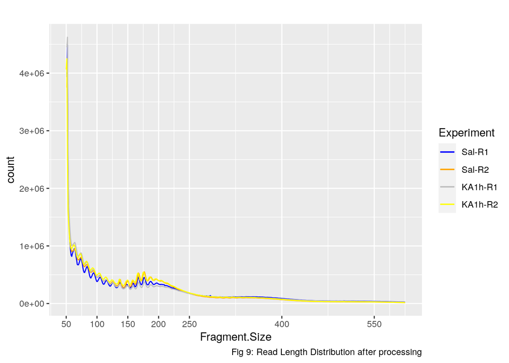

```r
# Create a data frame for each replicate
sal_1 <- data.frame("Fragment Size" = 50:600)
sal_1$count <- fragList$SRR8441346.fastq[27:577]
sal_1 <- sal_1[sal_1$count < 10000000, ]


sal_2 <- data.frame("Fragment Size" = 50:600)
sal_2$count <- fragList$SRR8441347_8.fastq[27:577]
sal_2 <- sal_2[sal_2$count < 10000000, ]


KA_1 <- data.frame("Fragment Size" = 50:600)
KA_1$count <- fragList$SRR8441349.fastq[27:577]
KA_1 <- KA_1[KA_1$count < 10000000, ]


KA_2 <- data.frame("Fragment Size" = 50:600)
KA_2$count <- fragList$SRR8441350_1.fastq[27:577]
KA_2 <- KA_2[KA_2$count < 10000000, ]



ggplot() +
geom_line(data=sal_1, aes(x=Fragment.Size, y=count, color='Sal-R1')) +
geom_line(data=sal_2, aes(x=Fragment.Size, y=count, color='Sal-R2')) +
geom_line(data=KA_1, aes(x=Fragment.Size,  y=count, color='KA1h-R1')) +
geom_line(data=KA_2, aes(x=Fragment.Size,  y=count, color='KA1h-R2')) +
scale_x_continuous(breaks =c(0, 50, 100, 150, 200, 250, 400, 550)) +
scale_color_manual(name = "Experiment", values = c("Sal-R1" = "blue", "Sal-R2" = "orange", "KA1h-R1" = "gray", "KA1h-R2" = "yellow")) +
labs(title = "", caption = "Fig 9: Read Length Distribution after processing")
```

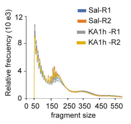

Fig 10: Read count distribution in the original paper

### b. Signal around TF

The objective of this section is to identify the footprint of 3 reported enhancers that shown increased accessibility during the SE condition. Such transcription factors (TF) are AP1, MEF2C and CTCF.

```r
suppressPackageStartupMessages({
  library(GenomicRanges)
  library(memes)
  library(Biostrings)
  library(AnnotationHub)
  library(MotifDb)
  library(universalmotif)
  library(PWMEnrich)
})
```

```
## See system.file("LICENSE", package="MotifDb") for use restrictions.
```

```r
dir.create("memes")
download.file("https://meme-suite.org/meme/meme-software/5.4.1/meme-5.4.1.tar.gz", "memes/meme.tar.gz")
```

```bash
tar xzvf memes/meme.tar.gz
cd meme-5.4.1
./configure --prefix=$HOME/meme --enable-build-libxml2 --enable-build-libxslt
make
make test
make install
```

Firstly, the motif for each TF must be identified. This can be done through the `MotifDb` library [13] as shown:

```r
# we search for "CTCF" in the motif database
motifs <- query(MotifDb, "CTCF")
# there are several matching motifs:
names(motifs)
```

```
##  [1] "Hsapiens-HOCOMOCOv10-CTCFL_HUMAN.H10MO.A"
##  [2] "Hsapiens-HOCOMOCOv10-CTCF_HUMAN.H10MO.A"
##  [3] "Mmusculus-HOCOMOCOv10-CTCF_MOUSE.H10MO.A"
##  [4] "Hsapiens-HOCOMOCOv11-core-A-CTCFL_HUMAN.H11MO.0.A"
##  [5] "Hsapiens-HOCOMOCOv11-core-A-CTCF_HUMAN.H11MO.0.A"
##  [6] "NA-HOMER-BORIS(Zf)/K562-CTCFL-ChIP-Seq(GSE32465)/Homer"
##  [7] "NA-HOMER-CTCF(Zf)/CD4+-CTCF-ChIP-Seq(Barski_et_al.)/Homer"
##  [8] "NA-HOMER-CTCF-SatelliteElement(Zf?)/CD4+-CTCF-ChIP-Seq(Barski_et_al.)/Homer"
##  [9] "Hsapiens-JASPAR_CORE-CTCF-MA0139.1"
## [10] "Hsapiens-JASPAR_2014-CTCF-MA0139.1"
## [11] "Dmelanogaster-JASPAR_2014-CTCF-MA0531.1"
## [12] "Hsapiens-jaspar2016-CTCF-MA0139.1"
## [13] "Dmelanogaster-jaspar2016-CTCF-MA0531.1"
## [14] "Hsapiens-jaspar2018-CTCF-MA0139.1"
## [15] "Dmelanogaster-jaspar2018-CTCF-MA0531.1"
## [16] "Hsapiens-jaspar2018-CTCFL-MA1102.1"
## [17] "Hsapiens-jolma2013-CTCF"
## [18] "Hsapiens-SwissRegulon-CTCFL.SwissRegulon"
## [19] "Hsapiens-SwissRegulon-CTCF.SwissRegulon"
```

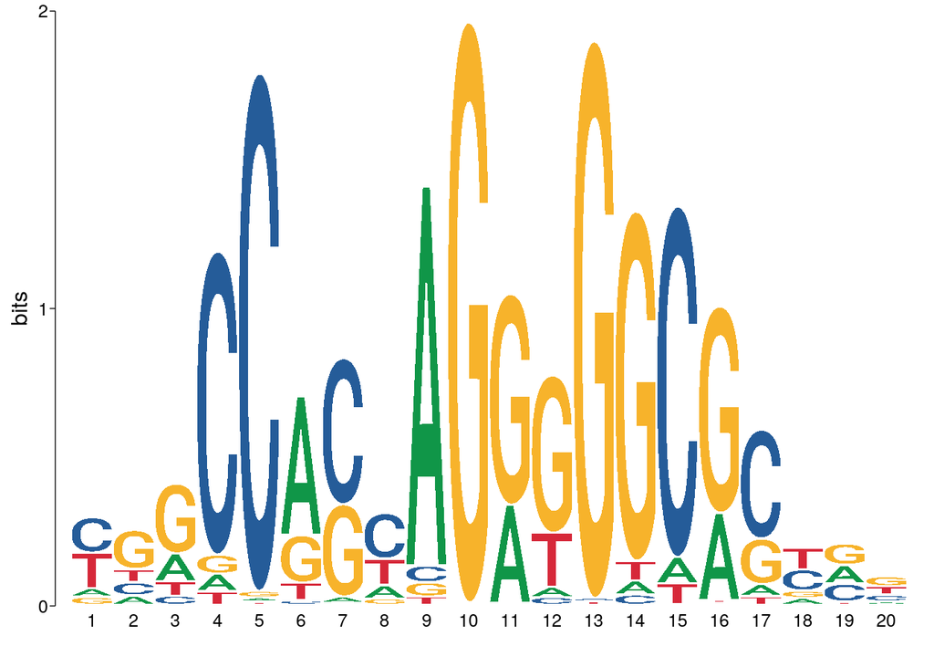

```
      Fig 11: CTCF Motif
```

```r
# we select one:
motif_CTCF <- motifs[["Mmusculus-HOCOMOCOv10-CTCF_MOUSE.H10MO.A"]]
# we visualize it:
view_motifs(motif_CTCF)
```

```r
# we search for "CTCF" in the motif database
motifs <- query(MotifDb, "MEF2C")
# there are several matching motifs:
names(motifs)
```

```
## [1] "Hsapiens-HOCOMOCOv10-MEF2C_HUMAN.H10MO.C"
## [2] "Mmusculus-HOCOMOCOv10-MEF2C_MOUSE.H10MO.B"
## [3] "Hsapiens-HOCOMOCOv11-core-A-MEF2C_HUMAN.H11MO.0.A"
## [4] "NA-HOMER-Mef2c(MADS)/GM12878-Mef2c-ChIP-Seq(GSE32465)/Homer"
## [5] "Hsapiens-JASPAR_2014-MEF2C-MA0497.1"
## [6] "Hsapiens-jaspar2016-MEF2C-MA0497.1"
## [7] "Hsapiens-jaspar2018-MEF2C-MA0497.1"
## [8] "Hsapiens-SwissRegulon-MEF2C.SwissRegulon"
```

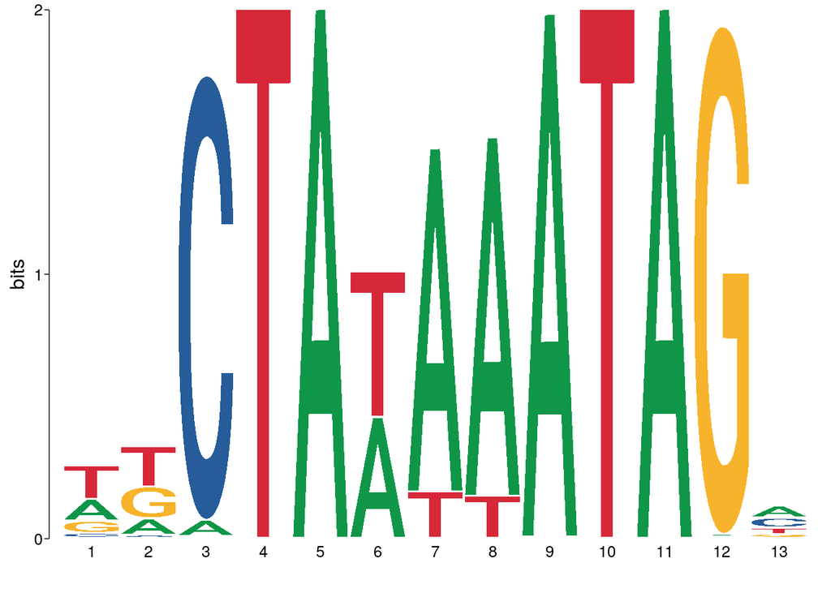

```
    Fig 12: MEF2C Motif
```

```r
# we select one:
motif_MEF2C <- motifs[["Mmusculus-HOCOMOCOv10-MEF2C_MOUSE.H10MO.B"]]
# we visualize it:
view_motifs(motif_MEF2C)
```

```r
# we search for "" in the motif database
motifs <- query(MotifDb, "AP1")
# there are several matching motifs:
names(motifs)
```

```
##  [1] "Hsapiens-HOCOMOCOv10-THAP1_HUMAN.H10MO.D"
##  [2] "Hsapiens-HOCOMOCOv11-core-B-THA11_HUMAN.H11MO.0.B"
##  [3] "Hsapiens-HOCOMOCOv11-core-C-THAP1_HUMAN.H11MO.0.C"
##  [4] "NA-HOMER-CEBP:AP1(bZIP)/ThioMac-CEBPb-ChIP-Seq(GSE21512)/Homer"
##  [5] "NA-HOMER-Jun-AP1(bZIP)/K562-cJun-ChIP-Seq(GSE31477)/Homer"
##  [6] "NA-HOMER-NFAT:AP1(RHD,bZIP)/Jurkat-NFATC1-ChIP-Seq(Jolma_et_al.)/Homer"
##  [7] "NA-HOMER-Ronin(THAP)/ES-Thap11-ChIP-Seq(GSE51522)/Homer"
##  [8] "Hsapiens-hPDI-ARFGAP1"
##  [9] "Hsapiens-hPDI-CDK2AP1"
## [10] "Hsapiens-hPDI-DAZAP1"
## [11] "Hsapiens-hPDI-NAP1L1"
## [12] "Hsapiens-hPDI-SMAP1L"
## [13] "Hsapiens-JASPAR_CORE-AP1-MA0099.2"
## [14] "Scerevisiae-JASPAR_CORE-HAP1-MA0312.1"
## [15] "Scerevisiae-JASPAR_CORE-RAP1-MA0359.1"
```

[output cut: 29 more lines]

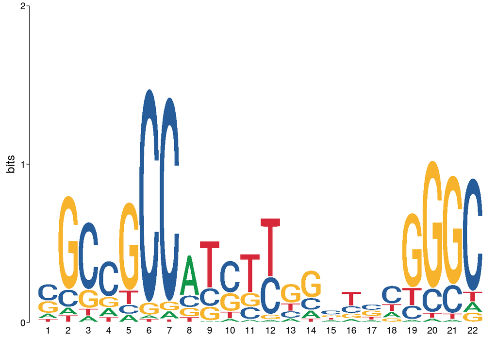

[output not shown]

```r
# we select one:
motif_AP1 <- motifs[["Hsapiens-HOCOMOCOv10-THAP1_HUMAN.H10MO.D"]]
# we visualize it:
view_motifs(motif_AP1)
```

Now, a series of steps are followed to arrive to the footprint of each TF for each condition (Control vs KA1h vs KA6h vs KA48h).

This step create variables for each peak file that contain the peaks centered and extract the sequences of each peak.

```r
ah <- AnnotationHub()
```

```
## snapshotDate(): 2020-10-27
```

```r
genome <- ah[["AH49773"]]
```

```
## loading from cache
```

```r
peak_centers_control <- resize(control_ATAC, fix="center", width=100)
peak_seqs_control <- memes::get_sequence(peak_centers_control, genome)

peak_centers_KA1h <- resize(KA1h_ATAC, fix="center", width=100)
peak_seqs_KA1h <- memes::get_sequence(peak_centers_KA1h, genome)

peak_centers_KA6h <- resize(KA6h_ATAC, fix="center", width=100)
peak_seqs_KA6h <- memes::get_sequence(peak_centers_KA6h, genome)

peak_centers_KA48h <- resize(KA48h_ATAC, fix="center", width=100)
peak_seqs_KA48h <- memes::get_sequence(peak_centers_KA48h, genome)
```

Then, the motifs of each TF are look through the peaks of each experimental condition. Note that the seqlevels are set to the UCSC pattern to avoid compatibility conflicts.

```r
moi_control_CTCF <- memes::runFimo(peak_seqs_control,  convert_motifs(motif_CTCF))
moi_KA1h_CTCF <- memes::runFimo(peak_seqs_KA1h,  convert_motifs(motif_CTCF))
moi_KA6h_CTCF <- memes::runFimo(peak_seqs_KA6h,  convert_motifs(motif_CTCF))
moi_KA48h_CTCF <- memes::runFimo(peak_seqs_KA48h,  convert_motifs(motif_CTCF))

moi_control_MEF2C <- memes::runFimo(peak_seqs_control,  convert_motifs(motif_MEF2C))
moi_KA1h_MEF2C <- memes::runFimo(peak_seqs_KA1h,  convert_motifs(motif_MEF2C))
moi_KA6h_MEF2C <- memes::runFimo(peak_seqs_KA6h,  convert_motifs(motif_MEF2C))
```

```
## No matches were detected
```

```r
moi_KA48h_MEF2C <- memes::runFimo(peak_seqs_KA48h,  convert_motifs(motif_MEF2C))

moi_control_AP1 <- memes::runFimo(peak_seqs_control,  convert_motifs(motif_AP1))
moi_KA1h_AP1 <- memes::runFimo(peak_seqs_KA1h,  convert_motifs(motif_AP1))
moi_KA6h_AP1 <- memes::runFimo(peak_seqs_KA6h,  convert_motifs(motif_AP1))
moi_KA48h_AP1 <- memes::runFimo(peak_seqs_KA48h,  convert_motifs(motif_AP1))

seqlevelsStyle(moi_control_CTCF) <- "UCSC"
seqlevelsStyle(moi_KA1h_CTCF) <- "UCSC"
moi_KA1h_CTCF <- keepSeqlevels(moi_KA1h_CTCF, c(paste("chr", 1:19, sep=""), "chrX"), pruning.mode="coarse")
seqlevelsStyle(moi_KA6h_CTCF) <- "UCSC"
seqlevelsStyle(moi_KA48h_CTCF) <- "UCSC"

seqlevelsStyle(moi_control_MEF2C) <- "UCSC"
seqlevelsStyle(moi_KA1h_MEF2C) <- "UCSC"
tryCatch(
    error = function(moi_KA6h_MEF2C) {moi_KA6h_MEF2C = NULL},
    seqlevelsStyle(moi_KA6h_MEF2C) <- "UCSC"
  )
seqlevelsStyle(moi_KA48h_MEF2C) <- "UCSC"

seqlevelsStyle(moi_control_AP1) <- "UCSC"
seqlevelsStyle(moi_KA1h_AP1) <- "UCSC"
seqlevelsStyle(moi_KA6h_AP1) <- "UCSC"
seqlevelsStyle(moi_KA48h_AP1) <- "UCSC"
```

Finally, each track is transformed into a matrix and plotted.

```r
tracks_Sal <- "coverage/ATAC_Sal.bw"
tracks_KA1h <- "coverage/ATAC_KA1h.bw"
tracks_KA6h <- "coverage/ATAC_KA6h.bw"
tracks_KA48h <- "coverage/ATAC_KA48h.bw"

signal_MEF2C_control <- signal2Matrix(tracks_Sal, moi_control_MEF2C, extend=1000, w=20)
```

```
## Reading coverage/ATAC_Sal.bw
```

```r
signal_MEF2C_KA1h <- signal2Matrix(tracks_KA1h, moi_KA1h_MEF2C, extend=1000, w=20)
```

```
## Reading coverage/ATAC_KA1h.bw
```

```r
signal_MEF2C_KA6h <- signal2Matrix(tracks_KA6h, moi_KA1h_MEF2C, extend=1000, w=20)
```

```
## Reading coverage/ATAC_KA6h.bw
```

```r
signal_MEF2C_KA48h <- signal2Matrix(tracks_KA48h, moi_KA1h_MEF2C, extend=1000, w=20)
```

```
## Reading coverage/ATAC_KA48h.bw
```

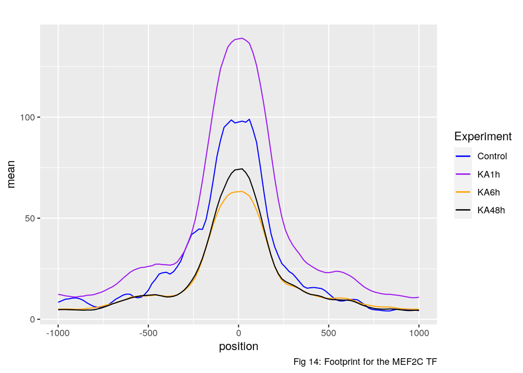

```r
signal_MEF2C_control <- meltSignals(signal_MEF2C_control)
signal_MEF2C_KA1h <- meltSignals(signal_MEF2C_KA1h)
signal_MEF2C_KA6h <- meltSignals(signal_MEF2C_KA6h)
signal_MEF2C_KA48h <- meltSignals(signal_MEF2C_KA48h)


ggplot() +
geom_line(signal_MEF2C_control, mapping = aes(position, mean, color='Control')) +
geom_line(signal_MEF2C_KA1h, mapping = aes(position, mean, color='KA1h')) +
geom_line(signal_MEF2C_KA6h, mapping = aes(position, mean, color='KA6h')) +
geom_line(signal_MEF2C_KA48h, mapping = aes(position, mean, color='KA48h')) +
scale_color_manual(name = "Experiment", values = c("Control" = "blue", "KA1h" = "purple", "KA6h" = "orange", "KA48h" = "black")) + labs(title = "", caption = "Fig 14: Footprint for the MEF2C TF")
```

```r
p1 <- scale_color_manual(name = "Experiment", values = c("Sal-R1" = "blue", "Sal-R2" = "orange", "KA1h-R1" = "gray", "KA1h-R2" = "yellow"))
```

```r
signal_AP1_control <- signal2Matrix(tracks_Sal, moi_control_AP1, extend=1000, w=20)
```

```
## Reading coverage/ATAC_Sal.bw
```

```r
signal_AP1_KA1h <- signal2Matrix(tracks_KA1h, moi_KA1h_AP1, extend=1000, w=20)
```

```
## Reading coverage/ATAC_KA1h.bw
```

```r
signal_AP1_KA6h <- signal2Matrix(tracks_KA6h, moi_KA1h_AP1, extend=1000, w=20)
```

```
## Reading coverage/ATAC_KA6h.bw
```

```r
signal_AP1_KA48h <- signal2Matrix(tracks_KA48h, moi_KA1h_AP1, extend=1000, w=20)
```

```
## Reading coverage/ATAC_KA48h.bw
```

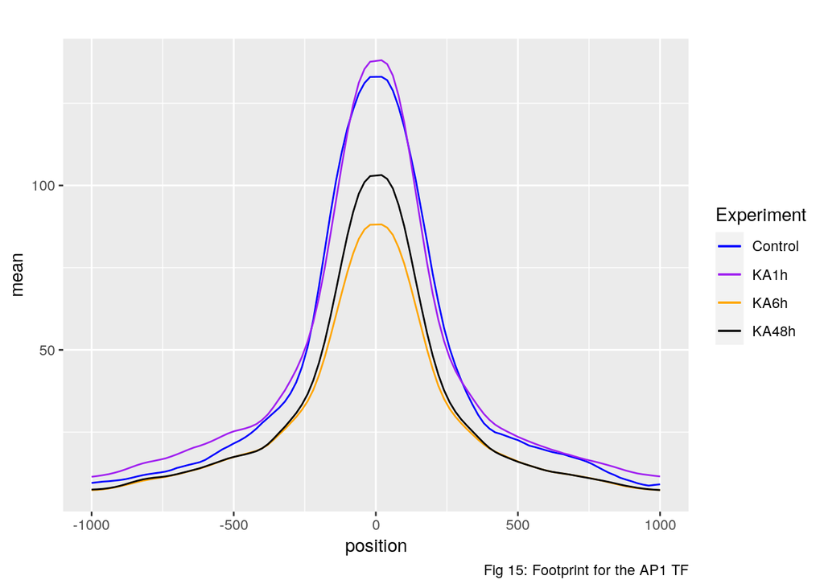

```r
signal_AP1_control <- meltSignals(signal_AP1_control)
signal_AP1_KA1h <- meltSignals(signal_AP1_KA1h)
signal_AP1_KA6h <- meltSignals(signal_AP1_KA6h)
signal_AP1_KA48h <- meltSignals(signal_AP1_KA48h)


ggplot() +
geom_line(signal_AP1_control, mapping = aes(position, mean, color='Control')) +
geom_line(signal_AP1_KA1h, mapping = aes(position, mean, color='KA1h')) +
geom_line(signal_AP1_KA6h, mapping = aes(position, mean, color='KA6h')) +
geom_line(signal_AP1_KA48h, mapping = aes(position, mean, color='KA48h')) +
scale_color_manual(name = "Experiment", values = c("Control" = "blue", "KA1h" = "purple", "KA6h" = "orange", "KA48h" = "black")) + labs(title = "", caption = "Fig 15: Footprint for the AP1 TF")
```

```r
p2 <- scale_color_manual(name = "Experiment", values = c("Sal-R1" = "blue", "Sal-R2" = "orange", "KA1h-R1" = "gray", "KA1h-R2" = "yellow"))
```

```r
signal_CTCF_control <- signal2Matrix(tracks_Sal, moi_control_CTCF, extend=1000, w=20)
```

```
## Reading coverage/ATAC_Sal.bw
```

```r
signal_CTCF_KA1h <- signal2Matrix(tracks_KA1h, moi_KA1h_CTCF, extend=1000, w=20)
```

```
## Reading coverage/ATAC_KA1h.bw
```

```r
signal_CTCF_KA6h <- signal2Matrix(tracks_KA6h, moi_KA6h_CTCF, extend=1000, w=20)
```

```
## Reading coverage/ATAC_KA6h.bw
```

```r
signal_CTCF_KA48h <- signal2Matrix(tracks_KA48h, moi_KA48h_CTCF, extend=1000, w=20)
```

```
## Reading coverage/ATAC_KA48h.bw
```

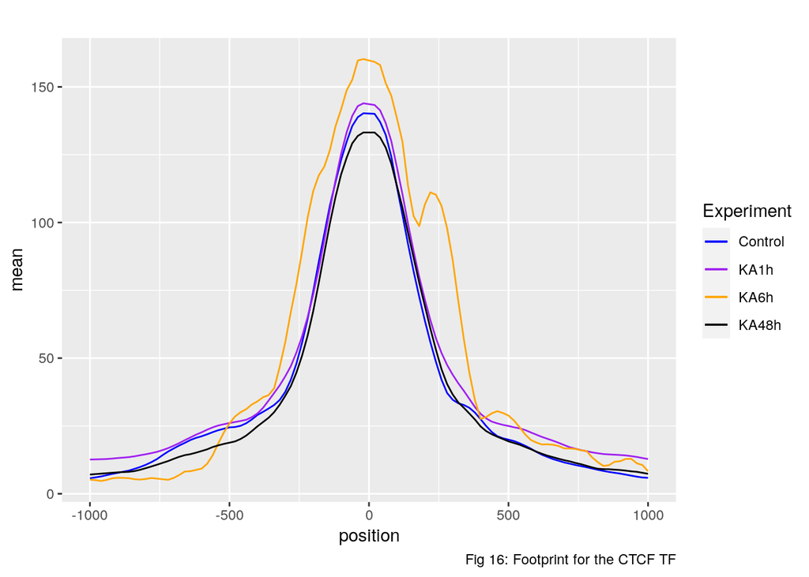

```r
signal_CTCF_control <- meltSignals(signal_CTCF_control)
signal_CTCF_KA1h <- meltSignals(signal_CTCF_KA1h)
signal_CTCF_KA6h <- meltSignals(signal_CTCF_KA6h)
signal_CTCF_KA48h <- meltSignals(signal_CTCF_KA48h)


ggplot() +
geom_line(signal_CTCF_control, mapping = aes(position, mean, color='Control')) +
geom_line(signal_CTCF_KA1h, mapping = aes(position, mean, color='KA1h')) +
geom_line(signal_CTCF_KA6h, mapping = aes(position, mean, color='KA6h')) +
geom_line(signal_CTCF_KA48h, mapping = aes(position, mean, color='KA48h')) +
scale_color_manual(name = "Experiment", values = c("Control" = "blue", "KA1h" = "purple", "KA6h" = "orange", "KA48h" = "black")) + labs(title = "", caption = "Fig 16: Footprint for the CTCF TF")
```

```r
p3 <- scale_color_manual(name = "Experiment", values = c("Sal-R1" = "blue", "Sal-R2" = "orange", "KA1h-R1" = "gray", "KA1h-R2" = "yellow"))
```

For comparison, the original images are included:

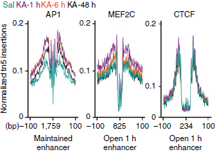

Fig 17: Original footprint for each TF

### c. Differential accesibility analysis

```r
suppressPackageStartupMessages({
library(SummarizedExperiment)
library(sechm)
library(edgeR)
library(cluster)
library(factoextra)
library(tidyverse)
})
```

To study the evolution of the DNA accesibility along time, a differential accesibility analysis has been performed on the ATAC-seq data.

Firstly, the number of reads found per region are calculated.

```r
bamfiles <- list.files("aligned", pattern="bam$", full=TRUE)
bamfiles <- bamfiles

names(bamfiles) <- gsub("\\.bam","",basename(bamfiles))

anno <- cbind(name=as.character(control_ATAC), as.data.frame(control_ATAC))
anno$width <- NULL
colnames(anno) <- c("GeneID", "Chr", "Start", "End", "Strand")

fc <- featureCounts( files=bamfiles,
                     isPairedEnd=TRUE,
                     annot.ext=anno,
                     readExtension3=50,
                     nthreads=25
                    )
```

[output not shown]

[output cut: 39 more lines]

[output not shown]

Then, we can store this information in a SummarizedExperiment object with proper format:

```r
se <- SummarizedExperiment(assays=list(counts=fc$counts), rowRanges=control_ATAC)

rowData(se)$input.count <- assay(se)
se <- se[,colnames(se)!="input.bam"]
se$condition <- c("CTRL","CTRL","KA1h","KA1h","KA6h","KA6h","KA48h", "KA48h")
se
```

```
## class: RangedSummarizedExperiment
## dim: 501 8
## metadata(0):
## assays(1): counts
## rownames(501): 1:7088669-7089074 1:7397844-7398305 ...
##   X:136741364-136741673 X:163908878-163909084
## rowData names(7): name score ... peak input.count
## colnames(8): SRR8441346.fastq.bam SRR8441347_8.fastq.bam ...
##   SRR8441354.fastq.bam SRR8441355.fastq.bam
## colData names(1): condition
```

In order to know the differences between the two biological replicates of the control experiment, the correlation between these two files can be plot:

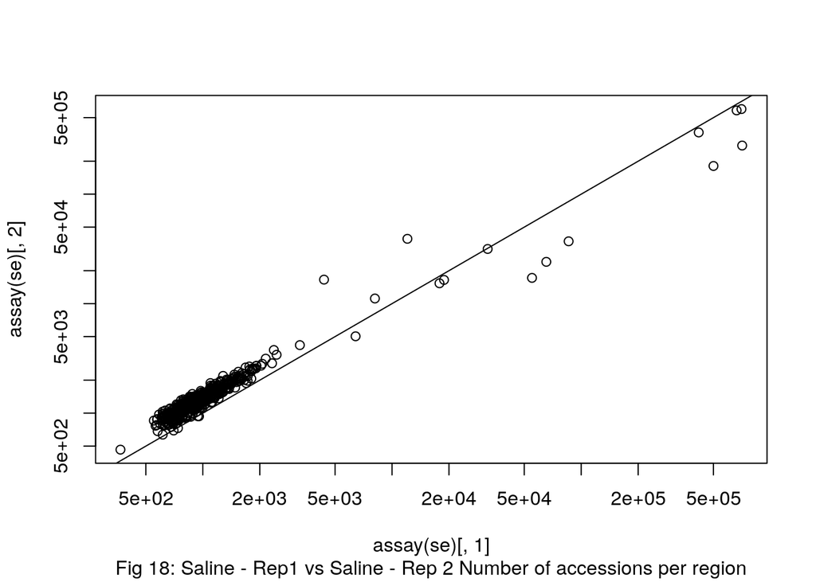

```r
plot(assay(se)[,1], assay(se)[,2], log="xy", sub="Fig 18: Saline - Rep1 vs Saline - Rep 2 Number of accessions per region")
abline(a=0, b=1)
```

The next step is to normalized the counts and transform them into count per million. Finally, a log transformation can be applied and stored in the original SummarizedExperiment object.

```r
dds <- DGEList(assay(se), group=se$condition)
dds <- calcNormFactors(dds)
assays(se)$tmm.logcpm <- log1p(cpm(dds))
```

In order to improve the visual representation of the differential accesibility analysis, kmeans clustering is run on the SummarizedExperiment object. However, as there is no correct number of clusters to which the regions can be mapped, a simple elbow algorithm is run to identify the most suited number of clusters.

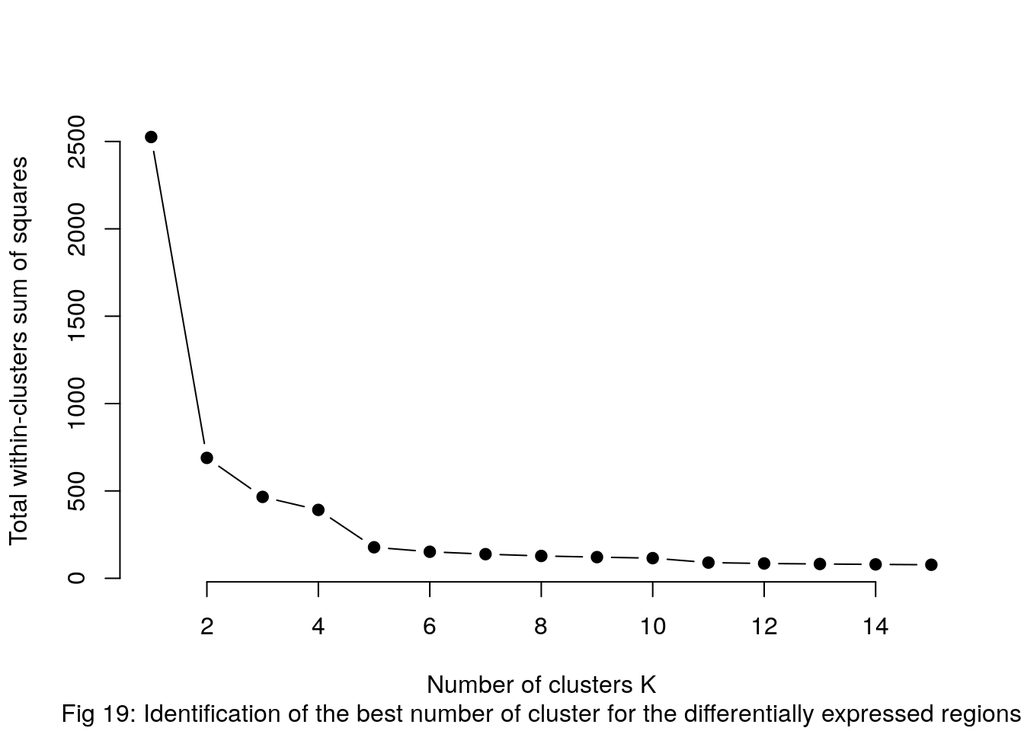

```r
wss <- function(k) {
  kmeans(assay(se, 2), k, nstart = 10 )$tot.withinss
}

# Compute and plot wss for k = 1 to k = 15
k.values <- 1:15

# extract wss for 2-15 clusters
wss_values <- map_dbl(k.values, wss)
plot(k.values, wss_values,
       type="b", pch = 19, frame = FALSE,
       xlab="Number of clusters K",
       ylab="Total within-clusters sum of squares",
       sub = "Fig 19: Identification of the best number of cluster for the differentially expressed regions")
```

And finally, a heatmap showing the differentially accessed regions can be plotted:

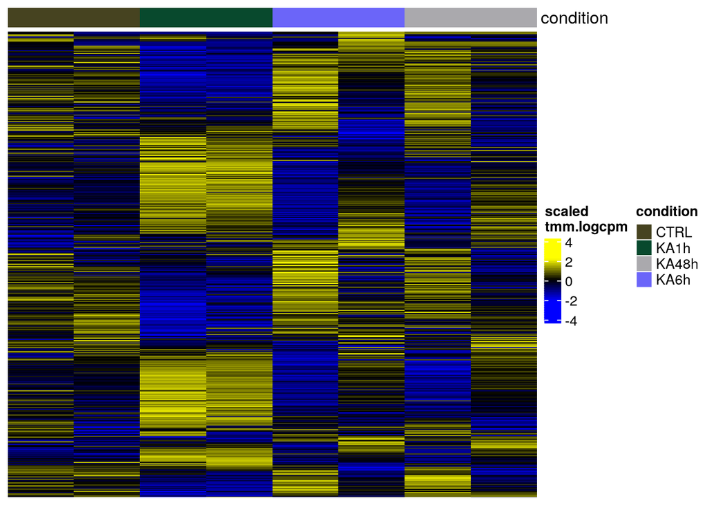

[output not shown]

```r
k2 <- kmeans(assay(se, 2), centers = 5, nstart = 25)

sechm(se, head(row.names(se),500), assayName="tmm.logcpm", do.scale = TRUE, cluster_rows = FALSE, toporder = k2$cluster)
```

For comparison purposes, the differentially accessed regions reported in the original article are included:

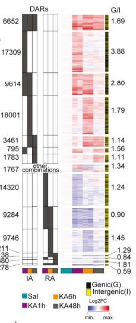

Fig 21: Differentially accessed regions reported in the original article

## 2.6. Sample Pseudotime Analysis

After the difference in the results of the previous sections, the PCA of the differentially accessed regions is calculated. The objective of this procedure is to compare what can be described as a pseudotime of the SE condition through the studied time.

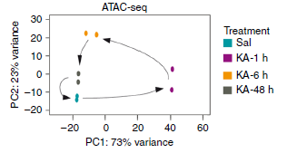

```r
library(pcaExplorer)
```

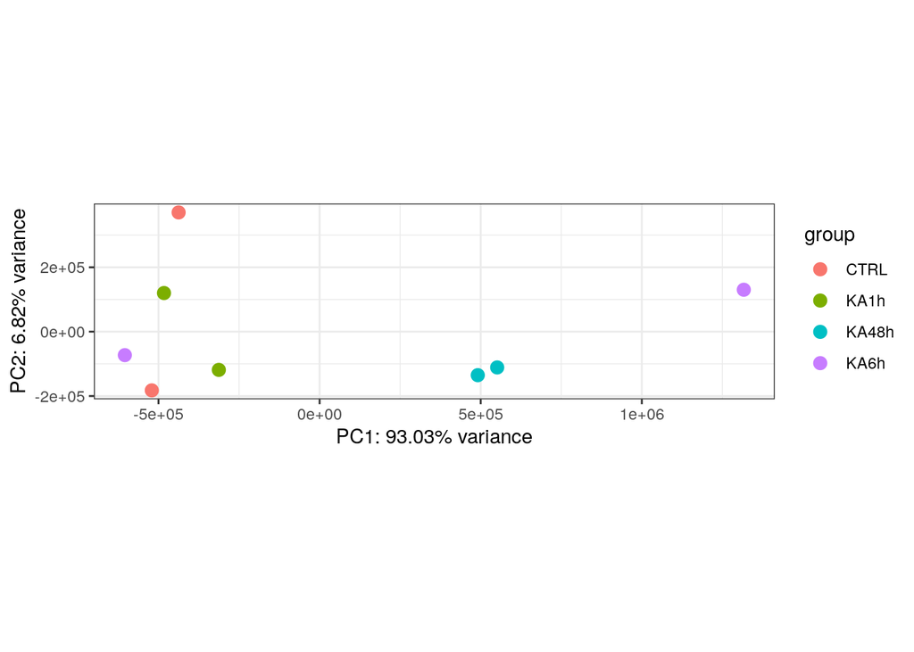

```r
pcaplot(se, text_labels = FALSE, ntop = 1000, pcX = 1, pcY = 2)
```

However, the result obtain in this replication study, once again differs from the results reported in the original paper.

# 3. Discussion

## 3.1. RNA-seq analysis

The results obtained during the differential expression analysis for the nuRNA-seq and the riboRNA-seq can be considered to be coincident with the ones reported in the original study. However, despite there are some minor differences in the number of upregulated/downregulated genes for the case of the nuRNA-seq, there exist more notable differences in the number of differentially expressed genes for the case of riboRNA-seq information. These differences might be due to the thresholds used in the log2FoldChange to delimit differentially expressed transcripts.

On the other hand, the enrichment analysis for the most upregulated transcripts shows clear differences with respect to the one expected. Nevertheless, some of the most enriched functions are present in both results showing a clear coherence between both analysis. Furthermore, it is possible that some of these differences are due to the hierarchical organization of the PANTHER tool, showing in some results higher levels of the organization that are less significant in the other results so only the lower organization levels are present.

## 3.2. ATAC-seq analysis

The results obtained after the ATAC-seq analysis show clear differences with respect to those published in by Fernandez-Albert et al.

The first and most relevant difference is that the distribution of the read lengths is different in the original article and in this replication study. And given that after the processing done in this project the results are still far to be similar, it is possible that the source of differences is upstream in the pipeline. More specifically, it has been noticed that the minimum read length considered for the trimming in the original article was 50bp, while the minimum read length considered in this study was 25bp.

This difference greatly impact downstream results, as different amount of mononucleosomes, dimers… would be reported. There is a direct impact of this result in the motif analysis, as there are some motifs that are not found in some replicates.

However, the problem with finding the motifs in the replicates might also come from another source, as it is the calculation of the consensus peaks. It is not clear how the authors managed the different replicates for his study, so it is difficult to do perform this processing in the same way.

# 4. Conclusions

After the analysis and interpretation of the nuRNA-seq, riboRNA-seq and ATAC-seq data, it can be stated that, despite some results were in the same line than in the original article as it is the case of the RNA-seq data, the ATAC-seq data shown remarkable differences with the expected outcome. Partly, some of these differences can be related to the bad processing of the ATAC-seq data. The trimming and the possible fine-tuned parameters in the downstream analysis may be the main sources of differences between the original article and this replication study.

From the results obtained, some conclusions can also be obtained for the epigenetic modifications occurring during SE condition. Right after the seizure episode, there is a clear disruption of the brain function, that can be observed both in the Differential Expression Analysis and in the Differential Accession Analysis. However, this disruption tends to be regulated with some delay, creating a predisposition to recover the pre-disease state. Nevertheless, this last statement is in contradiction with the pseudotime analysis performed in this study, in which this tendency is difficult to infer.

Despite the differences between the original article and this replication study, the most important conclusions that are stated in the original paper can also be obtained from this replication study, what shows the coherence between the results obtained and the ones expected.

# 6. References

[1] Fernandez-Albert, J., Lipinski, M., Lopez-Cascales, M. T., Rowley, M. J., Martin-Gonzalez, A. M., del Blanco, B., Corces, V. G., & Barco, A. (2019). Immediate and deferred epigenomic signatures of in vivo neuronal activation in mouse hippocampus. In Nature Neuroscience (Vol. 22, Issue 10, pp. 1718–1730). Springer Science and Business Media LLC. https://doi.org/10.1038/s41593-019-0476-2

[2] Yap, E.-L., & Greenberg, M. E. (2018). Activity-Regulated Transcription: Bridging the Gap between Neural Activity and Behavior. In Neuron (Vol. 100, Issue 2, pp. 330–348). Elsevier BV. https://doi.org/10.1016/j.neuron.2018.10.013

[3] Zucker, R. S., & Regehr, W. G. (2002). Short-Term Synaptic Plasticity. In Annual Review of Physiology (Vol. 64, Issue 1, pp. 355–405). Annual Reviews. https://doi.org/10.1146/annurev.physiol.64.092501.114547

[4] Hernandez, P. J., & Abel, T. (2008). The role of protein synthesis in memory consolidation: Progress amid decades of debate. In Neurobiology of Learning and Memory (Vol. 89, Issue 3, pp. 293–311). Elsevier BV. https://doi.org/10.1016/j.nlm.2007.09.010

[5] Tyssowski, K. M., & Gray, J. M. (2019). The neuronal stimulation–transcription coupling map. In Current Opinion in Neurobiology (Vol. 59, pp. 87–94). Elsevier BV. https://doi.org/10.1016/j.conb.2019.05.001

[6] Sung, Y.-J., & Ambron, R. T. (2004). Pathways that elicit long-term changes in gene expression in nociceptive neurons following nerve injury: contributions to neuropathic pain. In Neurological Research (Vol. 26, Issue 2, pp. 195–203). Informa UK Limited. https://doi.org/10.1179/016164104225013761

[7] Kolberg L, Raudvere U, Kuzmin I, Vilo J, Peterson H (2020). “gprofiler2– an R package for gene list functional enrichment analysis and namespace conversion toolset g:Profiler.” F1000Research, 9 (ELIXIR)(709). R package version 0.2.1.

[8] Raudvere, U., Kolberg, L., Kuzmin, I., Arak, T., Adler, P., Peterson, H. and Vilo, J., 2019. g: Profiler: a web server for functional enrichment analysis and conversions of gene lists (2019 update). Nucleic Acids Research, 47(W1), pp.W191-W198.; doi:10.1093/nar/gkz369

[9] Huaiyu Mi, Dustin Ebert, Anushya Muruganujan, Caitlin Mills, Laurent-Philippe Albou, Tremayne Mushayamaha and Paul D Thomas Nucl. Acids Res. (2020) doi: 10.1093/nar/gkaa1106s.

[10] Rezwani, M., Pourfathollah, A. A., & Noorbakhsh, F. (2022). rbioapi: user-friendly R interface to biologic web services’ API. In J. Wren (Ed.), Bioinformatics (Vol. 38, Issue 10, pp. 2952–2953). Oxford University Press (OUP). https://doi.org/10.1093/bioinformatics/btac172

[11] Love, M. I., Huber, W., & Anders, S. (2014). Moderated estimation of fold change and dispersion for RNA-seq data with DESeq2. In Genome Biology (Vol. 15, Issue 12). Springer Science and Business Media LLC. https://doi.org/10.1186/s13059-014-0550-8

[12] Ou, J., Liu, H., Yu, J., Kelliher, M. A., Castilla, L. H., Lawson, N. D., & Zhu, L. J. (2018). ATACseqQC: a Bioconductor package for post-alignment quality assessment of ATAC-seq data. In BMC Genomics (Vol. 19, Issue 1). Springer Science and Business Media LLC. https://doi.org/10.1186/s12864-018-4559-3

[13] Shannon P, Richards M (2022). MotifDb: An Annotated Collection of Protein-DNA Binding Sequence Motifs. R package version 1.38.0.